# S6_Evaluate_GAMLSS_ABCD

## 2 Step2 Model sensitivity analyses (bootstrap)

To determine reliability and stability of our GAMLSS fitted trajectories, and to obtain confidence intervals on all parameter estimates obtained from the GAMLSS fitting procedure as described above, we ran 1,000 bootstrap iterations with stratified sampling with replacement. The bootstrap replicates were stratified by sex and site, which maintains the relative proportions of the original datasets.

An average CV was computed for each edge to reflect the overall variability of bootstrap iterations.

```r
# WB_meanSC
bootstrapdir <- paste0(interfileFolder, "/bootstrap")
centile_female_boot <- list()
centile_male_boot <- list()
centile_boot <- list()
for (i in 1:1000) {
  centile.tmp <- readRDS(paste0(bootstrapdir, "/WB_SCmean/centile_bootstrap_", i, ".rds"))
  if (centile.tmp$converged==T){
    centile_F.tmp <- apply(centile.tmp$Centiles_female, c(2,3), mean)
    centile_female_boot[[i]] <- centile_F.tmp
    centile_M.tmp <- apply(centile.tmp$Centiles_male, c(2,3), mean)
    centile_male_boot[[i]] <- centile_M.tmp
    centile_boot[[i]] <- (centile_F.tmp+centile_M.tmp) / 2
  }else{
    centile_female_boot[[i]] <- NA
    centile_male_boot[[i]] <- NA
    centile_boot[[i]] <- NA
  }
}
print(paste0(length(which(is.na(centile_female_boot))), " iterations are not converged."))
```

```
[1] "0 iterations are not converged."
```

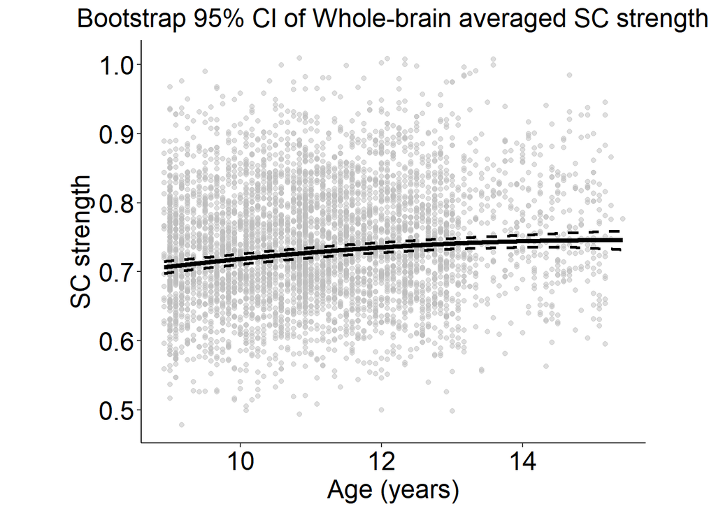

```r
centile_boot <- centile_boot[!is.na(centile_boot)]
centile_boot_P50 <- lapply(centile_boot, function(x) x[2,])
centile_boot_P50 <- do.call(rbind, centile_boot_P50)

sd_boot_P50 <- unlist(lapply(1:1000, function(x) sd(centile_boot_P50[,x])))
mean_boot_P50 <- unlist(lapply(1:1000, function(x) mean(centile_boot_P50[,x])))
cv_boot_P50 <- sd_boot_P50 / mean_boot_P50
Average_cv <- mean(cv_boot_P50) # 0.005877198

P97.5_boot_P50 <- unlist(lapply(1:1000, function(x) quantile(centile_boot_P50[,x], 0.975)))
P2.5_boot_P50 <- unlist(lapply(1:1000, function(x) quantile(centile_boot_P50[,x], 0.025)))

## Plot
agevector <- seq(min(SCdata.TD.trainset$age), max(SCdata.TD.trainset$age), length.out = 1000)

ggplot()+
  geom_point(data=SCdata.TD.trainset, aes(x=age, y=WB_SCmean), color="grey", alpha=0.5)+
  geom_line(aes(x=agevector, y=mean_boot_P50), linetype="solid", linewidth=1.5)+
  geom_line(aes(x=agevector, y=P97.5_boot_P50), linetype=2, linewidth=1)+
  geom_line(aes(x=agevector, y=P2.5_boot_P50), linetype=2, linewidth=1)+
  labs(x="Age (years)", y="SC strength", title="Bootstrap 95% CI of Whole-brain averaged SC strength")+
  theme_classic()+
  theme(axis.text=element_text(size=18, color="black"),
        axis.title =element_text(size=18, color="black"),aspect.ratio = 0.8,
        plot.background=element_rect(fill="white"),
        panel.background=element_rect(fill="white"),
        plot.title = element_text(size=18, hjust = 0.5),
        legend.text = element_text(size=18, color="black"), legend.title = element_text(size=20, color="black"))
```

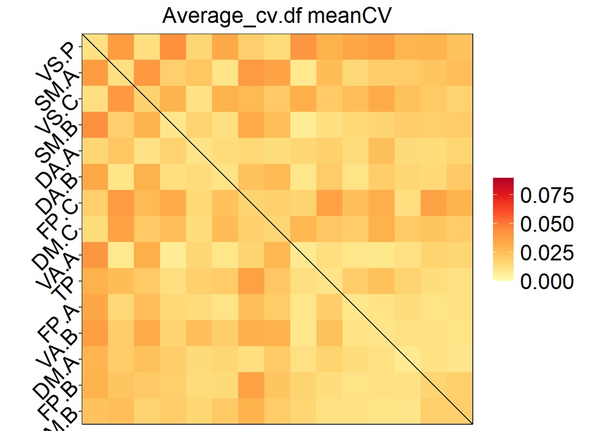

```r
ggsave(paste0(FigureFolder, "/Normative_Evaluation/bootstrap_95CI_WBmeanSC_all.tiff"), width=16, height=14, units = "cm")

## Each edge
if (! file.exists(paste0(resultFolder, "/Average_bootstrap_cv_GAMLSS.csv"))){
  Average_cv.df <- data.frame(SClabel = paste0("SC.", 1:element_num))
  for (x in 1:element_num){
    region <- paste0("SC.", x)

    centile_female_boot <- list()
    centile_male_boot <- list()
    centile_boot <- list()
    for (i in 1:1000) {
      if (file.exists(paste0(bootstrapdir, "/", region,"/centile_bootstrap_", i, ".rds"))){
        centile.tmp <- readRDS(paste0(bootstrapdir, "/", region,"/centile_bootstrap_", i, ".rds"))
        if (centile.tmp$converged==T){
          centile_F.tmp <- apply(centile.tmp$Centiles_female, c(2,3), mean)
          centile_female_boot[[i]] <- centile_F.tmp
          centile_M.tmp <- apply(centile.tmp$Centiles_male, c(2,3), mean)
          centile_male_boot[[i]] <- centile_M.tmp
          centile_boot[[i]] <- (centile_F.tmp+centile_M.tmp) / 2
        }else{
          centile_female_boot[[i]] <- NA
          centile_male_boot[[i]] <- NA
          centile_boot[[i]] <- NA
        }
      }
    }
    print(paste0(region, ": ", length(which(is.na(centile_female_boot))), " iterations are not converged."))

    centile_boot <- centile_boot[!is.na(centile_boot)]
    centile_boot_P50 <- lapply(centile_boot, function(x) x[2,])
    centile_boot_P50 <- do.call(rbind, centile_boot_P50)

    sd_boot_P50 <- unlist(lapply(1:1000, function(x) sd(centile_boot_P50[,x])))
    mean_boot_P50 <- unlist(lapply(1:1000, function(x) mean(centile_boot_P50[,x])))
    cv_boot_P50 <- sd_boot_P50 / mean_boot_P50
    Average_cv <- mean(cv_boot_P50) # 0.005877198
    Average_cv.df$meanCV[x] <- Average_cv
  }

  write.csv(Average_cv.df, paste0(resultFolder, "/Average_bootstrap_cv_GAMLSS.csv"), row.names = F)
}

Average_cv.df <- read.csv(paste0(resultFolder, "/Average_bootstrap_cv_GAMLSS.csv"))

PaletteSet <- list(Name="YlOrRd", drirection=1, lmmin = 0, lmmax = 0.09, anglex=45, angley=45, hjustx = 1, hjusty = 1, vjustx = 1, vjusty=0.3)
axeslabels=c("VS.P", "SM.A", "VS.C", "SM.B", "DA.A", "DA.B", "FP.C", "DM.C", "VA.A", "TP", "FP.A", "VA.B", "DM.A", "FP.B", "DM.B")
Mat.cv <- plotmatrix(dataname="Average_cv.df", variable="meanCV", ds.resolution=Yeoresolution.delLM, Pvar=NA, NAcol="white", lmthr=NA, axeslabels=axeslabels, axeslabelsGap=F, linerange_frame=NA, PaletteSet=PaletteSet)
Mat.cv
```

```r
ggsave(paste0(FigureFolder, "/Normative_Evaluation/Mat_CV.tiff"), Mat.cv, height = 14, width = 16, units = "cm")
```